# Dota 2 Analysis

Tyler Brinkley

CMSC320

[figure not shown]

# Introduction

### About the Topic

This tutorial is going to use Dota 2 to walk you through the data science pipeline. The topic Dota 2 has been chosen primarily because it’s an interest of mine and the data involved should have some interesting results

**What is Dota 2?** Dota is developed by Valve Corporation and can be defined as a competitive real time strategy game. The basic idea is that there are two teams of five, each person can choose from a pool of 119 characters, and the goal is to destroy the opponents main building. There are numerous more factors involved, and I [recommend to check out this wiki for more information](https://dota2.gamepedia.com/Dota_2). It can be thought as a chess game where each piece on the board is unique and the permutation of the possible board composition is countless, so every game is likely to always be different.

Dota is considered an [Esport game](https://en.wikipedia.org/wiki/Esports). This tutorial is going to use the data from [professional teams (click for the current list)](https://liquipedia.net/dota2/Portal:Teams)

### Data Science!

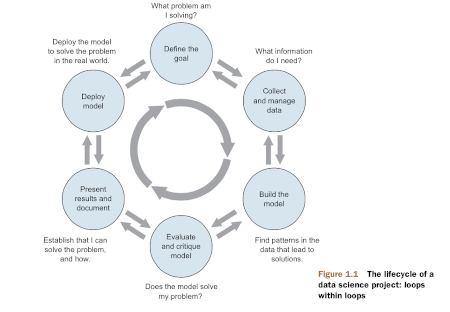

The areas this tutorial intends to cover:

I will be using **R** in this tutorial. Another option would be **Python**.

# The Goal

Before getting into the action of using your data science toolkit, you need to establish a goal that you’re trying to accomplish. What’s the problem at hand? What are you trying to solve? Figure out? Analyze?

We are going to analyze the performances of some of the top teams and hero performances (played by the professionals ) with relation to the patches that change the game.

# Data Wrangling

In order for us to do any sort of problem solving and data analyzing, we must acquire that data first! There are a few ways we can go about this. Some examples:

- Data Scrapping
  - e.g From websites [(Rvest is a useful tool for this)](https://www.rdocumentation.org/packages/rvest/versions/0.3.5)
- Third party Resources
  - Options: [(1) liquidpedia’s](https://liquipedia.net/dota2/Main_Page), [(2) Kaggle](https://www.kaggle.com/jsaguiar/dataset-update-with-opendota-api/data), [(3) DatDota](https://www.datdota.com/), [(4) OpenDota](https://www.opendota.com/), [(5) DotaBuff](https://www.dotabuff.com/), (6) API’s
- Run and administer our own experiments, trials, interviews, etc.
  - Not really appropriate here

The last option isn’t that feasible for this situation Data scrapping using an API is possible to do here but with the amount of data we want, the task would be fairly big for this tutorial. Since the data we want to use in this tutorial is already avaiable to use, we will go with this option.

For this tutorial, I will be using [DatDota](https://www.datdota.com/) to acquire files to import into the [Rstudio](https://rstudio.com/) project.

### Gathering The Data

We could have scrapped the data or used API’s available to us, but all the information we need can be easily obtained from DatDota. I went ahead and downloaded the files and they will be accessible on my GitHub page, or from DatDota (*Note:* I used patch intervals of 6 when querying the data from DatDota.

- [Team Performances](https://www.datdota.com/teams/performances?default=true)
- [Hero Performances](https://www.datdota.com/teams/performances?default=true)

### Environment Set up

We will now set up our environment to read and access the data from the files, allowing us to perform any needed operations from our data science toolkit.

I will be using the r library, readxl, to be able to read and convert excel files into data frames. data frame is our data structure (two dimensional) of rows and columns we will use to store, read, and organize data. Our data frames will be known as tidy data.

I will also be using the r library, kable, to display the data frames into nicely styled tables.

```r
# We use the library readxl to read excel files
library("readxl")
library("kableExtra")
library(tidyverse)
# Reading the excel files and making a data frame


### x_y indicates the patch range of the data file (x to y)
## HEROES
total_hero <- read_excel("heroes/hero_performances_7.0+.xltx")
hero_7.0_7.5 <- read_excel("heroes/hero_performances_7.0-7.5.xltx")
hero_7.5_7.10  <- read_excel("heroes/hero_performances_7.5-7.10.xltx")
hero_7.10_7.15 <- read_excel("heroes/hero_performances_7.10-7.15.xltx")
hero_7.15_7.20 <- read_excel("heroes/hero_performances_7.15-7.20.xltx")
hero_7.20_7.25 <- read_excel("heroes/hero_performances_7.20-7.25.xltx")

## TEAMS
total_teams <- read_csv("teams/team_performances_7.0+.csv")
teams_7.0_7.5 <- read_csv("teams/team_performances_7.0-7.5.csv")
teams_7.5_7.10  <- read_csv("teams/team_performances_7.5-7.10.csv")
teams_7.10_7.15 <- read_csv("teams/team_performances_7.10-7.15.csv")
teams_7.15_7.20 <- read_csv("teams/team_performances_7.15-7.20.csv")
teams_7.20_7.25 <- read_csv("teams/team_performances_7.20-7.25.csv")
```

Displaying a table of the hero stats played by professional. During the patch range: 7.00 to 7.25.

```r
## %>% is a pipe and will help with code interpretability
## It will pass the 'current step' on the LHS to the first argument on the RHS.


## Repeating the below, but for teams. I will exclude this for now.
#total_teams %>%
#  kable() %>%
#    kable_styling() %>%
#      scroll_box(box_css  = "background = black;", width = "100%", height ="500px",
#                 fixed_thead  = list(enabled = TRUE, background = "lightpurple"))

# Get our dataframe
total_hero %>%
  # pass it into kable, which will output a stylized table.
  kable() %>%
    kable_styling() %>%
      #Scrollable box for maneuverability of the table and other styling
      scroll_box(box_css  = "background = black;", width = "100%", height ="500px",
                 fixed_thead  = list(enabled = TRUE, background = "lightpurple"))
```

| Hero | Total Count | Wins | Losses | Winrate | As Radiant | As Dire | Kills | Deaths | Assists | KDA | Avg. KAL | GPM | XPM | Last Hits | Denies | LVL | HD | TD | HH | GS |
| --- | --- | --- | --- | --- | --- | --- | --- | --- | --- | --- | --- | --- | --- | --- | --- | --- | --- | --- | --- | --- |
| Rubick | 4588 | 2289 | 2299 | 0.4989 | 2248 | 2340 | 3.08 | 5.52 | 12.87 | 3.43 | 2.89 | 299 | 378 | 73 | 3 | 17 | 11049 | 273 | 306 | 9611 |
| Sand King | 3564 | 1648 | 1916 | 0.4624 | 1730 | 1834 | 3.19 | 5.88 | 12.79 | 3.17 | 2.72 | 348 | 425 | 122 | 3 | 18 | 12746 | 218 | 89 | 11216 |
| Disruptor | 2903 | 1426 | 1477 | 0.4912 | 1389 | 1514 | 2.58 | 6.15 | 14.25 | 3.09 | 2.74 | 256 | 326 | 35 | 3 | 16 | 8350 | 169 | 168 | 8474 |
| Ember Spirit | 2852 | 1436 | 1416 | 0.5035 | 1443 | 1409 | 7.66 | 4.00 | 11.02 | 5.54 | 4.67 | 498 | 578 | 245 | 9 | 21 | 26448 | 1027 | 86 | 16791 |
| Tiny | 2817 | 1313 | 1504 | 0.4661 | 1528 | 1289 | 6.33 | 5.07 | 9.86 | 4.09 | 3.19 | 423 | 486 | 174 | 10 | 19 | 18503 | 2253 | 124 | 13757 |
| Earth Spirit | 2798 | 1398 | 1400 | 0.4996 | 1369 | 1429 | 3.01 | 6.18 | 14.78 | 3.26 | 2.88 | 271 | 354 | 40 | 2 | 17 | 11307 | 154 | 497 | 8745 |
| Puck | 2728 | 1287 | 1441 | 0.4718 | 1364 | 1364 | 5.73 | 4.13 | 10.76 | 4.73 | 4.00 | 473 | 540 | 214 | 11 | 20 | 19160 | 1090 | 80 | 16050 |
| Earthshaker | 2601 | 1307 | 1294 | 0.5025 | 1240 | 1361 | 3.13 | 5.57 | 12.68 | 3.40 | 2.84 | 296 | 394 | 85 | 4 | 18 | 11982 | 371 | 50 | 9794 |
| Batrider | 2573 | 1275 | 1298 | 0.4955 | 1313 | 1260 | 4.31 | 5.43 | 12.96 | 3.83 | 3.18 | 358 | 436 | 136 | 4 | 18 | 13334 | 181 | 78 | 11482 |
| Lifestealer | 2424 | 1198 | 1226 | 0.4942 | 1259 | 1165 | 6.69 | 3.07 | 8.58 | 5.91 | 4.97 | 538 | 560 | 253 | 17 | 21 | 20158 | 4122 | 1396 | 18045 |
| Juggernaut | 2405 | 1140 | 1265 | 0.4740 | 1174 | 1231 | 6.92 | 3.35 | 8.04 | 5.28 | 4.47 | 566 | 559 | 288 | 16 | 21 | 18090 | 4747 | 2644 | 18906 |
| Tusk | 2379 | 1100 | 1279 | 0.4624 | 1227 | 1152 | 3.13 | 6.72 | 14.32 | 2.95 | 2.60 | 284 | 377 | 45 | 2 | 17 | 10193 | 177 | 652 | 8857 |
| Nyx Assassin | 2320 | 1289 | 1031 | 0.5556 | 1165 | 1155 | 2.39 | 6.15 | 12.81 | 2.93 | 2.47 | 285 | 376 | 44 | 3 | 17 | 10283 | 204 | 168 | 9090 |
| Clockwerk | 2231 | 1158 | 1073 | 0.5190 | 1146 | 1085 | 4.36 | 6.31 | 13.38 | 3.40 | 2.81 | 298 | 360 | 70 | 21 | 17 | 16599 | 227 | 317 | 9829 |
| Lina | 2156 | 1022 | 1134 | 0.4740 | 1076 | 1080 | 7.30 | 5.25 | 8.28 | 3.56 | 2.97 | 508 | 563 | 265 | 9 | 21 | 20032 | 2814 | 657 | 17274 |
| Gyrocopter | 2141 | 1091 | 1050 | 0.5096 | 1071 | 1070 | 7.76 | 4.05 | 10.11 | 5.28 | 4.42 | 579 | 567 | 321 | 16 | 21 | 27312 | 4485 | 15 | 19748 |
| Centaur Warrunner | 2132 | 1078 | 1054 | 0.5056 | 1053 | 1079 | 3.43 | 4.92 | 12.43 | 3.94 | 3.22 | 404 | 472 | 183 | 8 | 19 | 11909 | 2452 | 97 | 13012 |
| Bane | 2128 | 1141 | 987 | 0.5362 | 1087 | 1041 | 2.61 | 6.78 | 11.89 | 2.51 | 2.14 | 238 | 329 | 25 | 4 | 16 | 7320 | 214 | 140 | 7947 |
| Dragon Knight | 2106 | 1092 | 1014 | 0.5185 | 992 | 1114 | 5.30 | 4.10 | 9.36 | 4.37 | 3.57 | 489 | 535 | 229 | 10 | 20 | 16615 | 4353 | 19 | 16105 |
| Shadow Shaman | 1964 | 969 | 995 | 0.4934 | 955 | 1009 | 2.82 | 6.99 | 11.12 | 2.24 | 1.99 | 297 | 379 | 75 | 5 | 17 | 9679 | 2648 | 54 | 9196 |
| Witch Doctor | 1958 | 896 | 1062 | 0.4576 | 997 | 961 | 4.12 | 6.58 | 11.02 | 2.65 | 2.30 | 266 | 320 | 37 | 3 | 16 | 9641 | 342 | 2988 | 8762 |
| Kunkka | 1954 | 954 | 1000 | 0.4882 | 953 | 1001 | 4.26 | 4.27 | 12.35 | 4.78 | 3.89 | 424 | 493 | 200 | 7 | 19 | 15851 | 1172 | 326 | 14167 |
| Outworld Devourer | 1943 | 967 | 976 | 0.4977 | 997 | 946 | 7.24 | 4.00 | 6.89 | 4.34 | 3.53 | 530 | 572 | 267 | 19 | 21 | 20032 | 1531 | 22 | 17542 |
| Terrorblade | 1942 | 1019 | 923 | 0.5247 | 989 | 953 | 6.66 | 3.40 | 8.19 | 4.93 | 4.37 | 649 | 550 | 384 | 13 | 21 | 22288 | 7306 | 17 | 22409 |
| Weaver | 1913 | 959 | 954 | 0.5013 | 951 | 962 | 7.55 | 3.60 | 10.20 | 5.84 | 4.93 | 494 | 578 | 226 | 11 | 21 | 20201 | 3424 | 81 | 17045 |
| Shadow Fiend | 1908 | 914 | 994 | 0.4790 | 957 | 951 | 7.35 | 4.18 | 8.15 | 4.36 | 3.71 | 594 | 602 | 320 | 20 | 21 | 21176 | 4198 | 322 | 19312 |
| Queen of Pain | 1907 | 937 | 970 | 0.4913 | 933 | 974 | 8.52 | 3.56 | 9.02 | 5.82 | 4.93 | 527 | 586 | 260 | 18 | 21 | 23611 | 2216 | 99 | 17901 |
| Mirana | 1895 | 997 | 898 | 0.5261 | 956 | 939 | 6.86 | 3.93 | 12.12 | 5.70 | 4.83 | 451 | 505 | 205 | 9 | 20 | 17890 | 2099 | 581 | 15465 |
| Ancient Apparition | 1889 | 988 | 901 | 0.5230 | 909 | 980 | 3.50 | 5.80 | 15.20 | 3.73 | 3.22 | 274 | 330 | 36 | 3 | 16 | 10270 | 239 | 233 | 9549 |
| Razor | 1887 | 918 | 969 | 0.4865 | 949 | 938 | 6.77 | 4.45 | 9.26 | 4.40 | 3.60 | 512 | 561 | 266 | 18 | 21 | 20906 | 2683 | 36 | 17172 |

[output cut: 89 more lines]

### Tidying and Cleaning

Although the imported data is good, I still believe there could be some corrections and adjustments. For instance, some of the column names are not clearly defined, so first time readers won’t understand them (I’m assuming you know some of the details of the game still). There are some columns that aren’t going to be needed, so we can drop them. The time column imported from excel needs to be displayed correctly. Lastly, I only care about some of the professional teams, so I will be picking a few rows from the many available.

**Note:** The values of the variables for each observation are averages for the number of games they played.

```r
library(data.table)

###################
###Team Portion####
###################

## We are going to define a few functions to carry out what we want
## due to having multiple data files.

## Removing unwanted colomns
RemoveCol <- function(team) {
    team <- subset(team, select = -c(2)) %>% subset(select = -c(Shift,Overall))
    return(team)
}
# Rename Columns
RenameCols <- function(x) {
    setnames(x, c("Team","Games Played","Wins", "Losses", "Winrate","Radiant Sided Games", "Dire Sided Games",
                  "Kills"," Deaths", "Assists", "Gold Per Minute", "Experience Per Minute", "Creep Last Hits",
                  "Denies", "Won Match Avg Time", "Lost Match Avg Time"))
    return(x)
}

## Select teams
SelectTeams <- function(teams) {
    teams <- subset(teams, Team == "Team Secret" | Team == "Evil Geniuses" | Team == "Alliance" |
                      Team == "Newbee" | Team == "Fnatic" | Team == "OG" | Team == "Vici Gaming" |
                    Team == "Team Liquid"| Team == "virtus.pro"| Team == "LGD.Forever Young" |
                      Team == "INVICTUS GAMING" | Team == "compLexity Gaming" | Team == "compLexity Gaming" |
                      Team == "Natus Vincer" | Team == "OpTic Gaming" | Team == "PSG.LGD" |
                      Team == "TNC Predator")
}

##  Apply and Save our changes
total_teams <- total_teams %>% RemoveCol() %>% RenameCols() %>% SelectTeams()
teams_patchset_1 <-  teams_7.5_7.10 %>% RemoveCol() %>% RenameCols() %>% SelectTeams()
teams_patchset_2  <-  teams_7.5_7.10 %>% RemoveCol() %>% RenameCols() %>% SelectTeams()
teams_patchset_3 <-  teams_7.10_7.15 %>% RemoveCol() %>% RenameCols() %>% SelectTeams()
teams_patchset_4 <-  teams_7.15_7.20 %>% RemoveCol() %>% RenameCols() %>% SelectTeams()
teams_patchset_5 <-  teams_7.20_7.25 %>% RemoveCol() %>% RenameCols() %>% SelectTeams()

###################
### Hero Portion###
###################

RenameCols <- function(x) {
    setnames(x, c("Hero","Total_Games_Picked","Wins", "Losses", "Winrate","Radiant_Sided Games",
                  "Dire_Sided_Games", "Kills"," Deaths", "Assists", "Kill_Death Assist_Ratio ",
                  "Assits_Per_Life", "Gold_Per_Minute", "Experience_Per_Minute",  "Last_Hits", "Denies",
                  "Level", "Hero_Damage", "Tower_Damage", "Hero_Healing", "Gold_Spent"))
    return(x)
}

total_hero <- total_hero %>% RenameCols()
hero_patchset_1 <- hero_7.0_7.5 %>% RenameCols()
hero_patchset_2  <- hero_7.5_7.10 %>% RenameCols()
hero_patchset_3 <- hero_7.10_7.15 %>% RenameCols()
hero_patchset_4 <- hero_7.15_7.20  %>% RenameCols()
hero_patchset_5 <- hero_7.20_7.25 %>% RenameCols()
```

```r
total_teams %>%
  kable() %>%
    kable_styling() %>%
      scroll_box(box_css  = "background = black;", width = "100%", height ="500px",
                fixed_thead  = list(enabled = TRUE, background = "lightpurple"))
```

| Team | Games Played | Wins | Losses | Winrate | Radiant Sided Games | Dire Sided Games | Kills | Deaths | Assists | Gold Per Minute | Experience Per Minute | Creep Last Hits | Denies | Won Match Avg Time | Lost Match Avg Time |
| --- | --- | --- | --- | --- | --- | --- | --- | --- | --- | --- | --- | --- | --- | --- | --- |
| Vici Gaming | 926 | 568 | 358 | 61.34% | 437 | 489 | 25.99 | 22.24 | 60.46 | 2138 | 2470 | 893 | 45 | 36:08:00 | 38:47:00 |
| PSG.LGD | 841 | 529 | 312 | 62.90% | 430 | 411 | 26.04 | 23.70 | 57.79 | 2159 | 2446 | 881 | 44 | 35:33:00 | 39:04:00 |
| TNC Predator | 767 | 449 | 318 | 58.54% | 389 | 378 | 24.80 | 23.37 | 58.25 | 2183 | 2427 | 958 | 41 | 39:08:00 | 40:22:00 |
| Team Secret | 758 | 528 | 230 | 69.66% | 429 | 329 | 26.40 | 20.55 | 61.35 | 2194 | 2474 | 900 | 44 | 36:13:00 | 39:57:00 |
| Team Liquid | 750 | 469 | 281 | 62.53% | 369 | 381 | 26.07 | 24.11 | 58.44 | 2148 | 2409 | 869 | 44 | 36:16:00 | 38:31:00 |
| Newbee | 722 | 369 | 353 | 51.11% | 311 | 411 | 24.03 | 23.44 | 56.30 | 2093 | 2373 | 911 | 43 | 38:22:00 | 37:11:00 |
| Evil Geniuses | 706 | 453 | 253 | 64.16% | 349 | 357 | 25.57 | 21.96 | 58.39 | 2167 | 2411 | 868 | 46 | 34:39:00 | 39:52:00 |
| INVICTUS GAMING | 672 | 389 | 283 | 57.89% | 332 | 340 | 24.68 | 22.35 | 57.64 | 2134 | 2464 | 908 | 44 | 37:03:00 | 38:21:00 |
| Fnatic | 667 | 402 | 265 | 60.27% | 331 | 336 | 25.90 | 23.05 | 59.41 | 2158 | 2459 | 923 | 44 | 37:57:00 | 39:20:00 |
| OG | 645 | 405 | 240 | 62.79% | 309 | 336 | 26.18 | 25.51 | 59.93 | 2127 | 2379 | 823 | 41 | 35:35:00 | 38:19:00 |
| Alliance | 633 | 329 | 304 | 51.97% | 291 | 342 | 25.78 | 23.89 | 58.83 | 2133 | 2462 | 941 | 43 | 37:56:00 | 39:38:00 |
| compLexity Gaming | 570 | 301 | 269 | 52.81% | 268 | 302 | 24.12 | 23.72 | 54.66 | 2097 | 2305 | 852 | 44 | 36:11:00 | 39:04:00 |
| LGD.Forever Young | 341 | 187 | 154 | 54.84% | 182 | 159 | 25.04 | 22.55 | 59.30 | 2003 | 2258 | 794 | 44 | 39:10:00 | 36:39:00 |
| OpTic Gaming | 308 | 180 | 128 | 58.44% | 147 | 161 | 24.44 | 24.33 | 53.51 | 2082 | 2282 | 815 | 41 | 35:53:00 | 38:48:00 |
| Newbee | 207 | 114 | 93 | 55.07% | 113 | 94 | 25.13 | 21.65 | 59.41 | 2181 | 2461 | 933 | 46 | 36:16:00 | 37:29:00 |

```r
# Get our dataframe
total_hero %>%
  # pass it into kable, which will output a stylized table.
  kable() %>%
    kable_styling() %>%
      #Scrollable box for maneuverability of the table and other styling
      scroll_box(box_css  = "background = black;", width = "100%", height ="500px",
                 fixed_thead  = list(enabled = TRUE, background = "lightpurple"))
```

| Hero | Total Games Picked | Wins | Losses | Winrate | Radiant Sided Games | Dire Sided Games | Kills | Deaths | Assists | Kill Death Assist Ratio | Assits Per Life | Gold Per Minute | Experience Per Minute | Last Hits | Denies | Level | Hero Damage | Tower Damage | Hero Healing | Gold Spent |
| --- | --- | --- | --- | --- | --- | --- | --- | --- | --- | --- | --- | --- | --- | --- | --- | --- | --- | --- | --- | --- |
| Rubick | 4588 | 2289 | 2299 | 0.4989 | 2248 | 2340 | 3.08 | 5.52 | 12.87 | 3.43 | 2.89 | 299 | 378 | 73 | 3 | 17 | 11049 | 273 | 306 | 9611 |
| Sand King | 3564 | 1648 | 1916 | 0.4624 | 1730 | 1834 | 3.19 | 5.88 | 12.79 | 3.17 | 2.72 | 348 | 425 | 122 | 3 | 18 | 12746 | 218 | 89 | 11216 |
| Disruptor | 2903 | 1426 | 1477 | 0.4912 | 1389 | 1514 | 2.58 | 6.15 | 14.25 | 3.09 | 2.74 | 256 | 326 | 35 | 3 | 16 | 8350 | 169 | 168 | 8474 |
| Ember Spirit | 2852 | 1436 | 1416 | 0.5035 | 1443 | 1409 | 7.66 | 4.00 | 11.02 | 5.54 | 4.67 | 498 | 578 | 245 | 9 | 21 | 26448 | 1027 | 86 | 16791 |
| Tiny | 2817 | 1313 | 1504 | 0.4661 | 1528 | 1289 | 6.33 | 5.07 | 9.86 | 4.09 | 3.19 | 423 | 486 | 174 | 10 | 19 | 18503 | 2253 | 124 | 13757 |
| Earth Spirit | 2798 | 1398 | 1400 | 0.4996 | 1369 | 1429 | 3.01 | 6.18 | 14.78 | 3.26 | 2.88 | 271 | 354 | 40 | 2 | 17 | 11307 | 154 | 497 | 8745 |
| Puck | 2728 | 1287 | 1441 | 0.4718 | 1364 | 1364 | 5.73 | 4.13 | 10.76 | 4.73 | 4.00 | 473 | 540 | 214 | 11 | 20 | 19160 | 1090 | 80 | 16050 |
| Earthshaker | 2601 | 1307 | 1294 | 0.5025 | 1240 | 1361 | 3.13 | 5.57 | 12.68 | 3.40 | 2.84 | 296 | 394 | 85 | 4 | 18 | 11982 | 371 | 50 | 9794 |
| Batrider | 2573 | 1275 | 1298 | 0.4955 | 1313 | 1260 | 4.31 | 5.43 | 12.96 | 3.83 | 3.18 | 358 | 436 | 136 | 4 | 18 | 13334 | 181 | 78 | 11482 |
| Lifestealer | 2424 | 1198 | 1226 | 0.4942 | 1259 | 1165 | 6.69 | 3.07 | 8.58 | 5.91 | 4.97 | 538 | 560 | 253 | 17 | 21 | 20158 | 4122 | 1396 | 18045 |
| Juggernaut | 2405 | 1140 | 1265 | 0.4740 | 1174 | 1231 | 6.92 | 3.35 | 8.04 | 5.28 | 4.47 | 566 | 559 | 288 | 16 | 21 | 18090 | 4747 | 2644 | 18906 |
| Tusk | 2379 | 1100 | 1279 | 0.4624 | 1227 | 1152 | 3.13 | 6.72 | 14.32 | 2.95 | 2.60 | 284 | 377 | 45 | 2 | 17 | 10193 | 177 | 652 | 8857 |
| Nyx Assassin | 2320 | 1289 | 1031 | 0.5556 | 1165 | 1155 | 2.39 | 6.15 | 12.81 | 2.93 | 2.47 | 285 | 376 | 44 | 3 | 17 | 10283 | 204 | 168 | 9090 |
| Clockwerk | 2231 | 1158 | 1073 | 0.5190 | 1146 | 1085 | 4.36 | 6.31 | 13.38 | 3.40 | 2.81 | 298 | 360 | 70 | 21 | 17 | 16599 | 227 | 317 | 9829 |
| Lina | 2156 | 1022 | 1134 | 0.4740 | 1076 | 1080 | 7.30 | 5.25 | 8.28 | 3.56 | 2.97 | 508 | 563 | 265 | 9 | 21 | 20032 | 2814 | 657 | 17274 |
| Gyrocopter | 2141 | 1091 | 1050 | 0.5096 | 1071 | 1070 | 7.76 | 4.05 | 10.11 | 5.28 | 4.42 | 579 | 567 | 321 | 16 | 21 | 27312 | 4485 | 15 | 19748 |
| Centaur Warrunner | 2132 | 1078 | 1054 | 0.5056 | 1053 | 1079 | 3.43 | 4.92 | 12.43 | 3.94 | 3.22 | 404 | 472 | 183 | 8 | 19 | 11909 | 2452 | 97 | 13012 |
| Bane | 2128 | 1141 | 987 | 0.5362 | 1087 | 1041 | 2.61 | 6.78 | 11.89 | 2.51 | 2.14 | 238 | 329 | 25 | 4 | 16 | 7320 | 214 | 140 | 7947 |
| Dragon Knight | 2106 | 1092 | 1014 | 0.5185 | 992 | 1114 | 5.30 | 4.10 | 9.36 | 4.37 | 3.57 | 489 | 535 | 229 | 10 | 20 | 16615 | 4353 | 19 | 16105 |
| Shadow Shaman | 1964 | 969 | 995 | 0.4934 | 955 | 1009 | 2.82 | 6.99 | 11.12 | 2.24 | 1.99 | 297 | 379 | 75 | 5 | 17 | 9679 | 2648 | 54 | 9196 |
| Witch Doctor | 1958 | 896 | 1062 | 0.4576 | 997 | 961 | 4.12 | 6.58 | 11.02 | 2.65 | 2.30 | 266 | 320 | 37 | 3 | 16 | 9641 | 342 | 2988 | 8762 |
| Kunkka | 1954 | 954 | 1000 | 0.4882 | 953 | 1001 | 4.26 | 4.27 | 12.35 | 4.78 | 3.89 | 424 | 493 | 200 | 7 | 19 | 15851 | 1172 | 326 | 14167 |
| Outworld Devourer | 1943 | 967 | 976 | 0.4977 | 997 | 946 | 7.24 | 4.00 | 6.89 | 4.34 | 3.53 | 530 | 572 | 267 | 19 | 21 | 20032 | 1531 | 22 | 17542 |
| Terrorblade | 1942 | 1019 | 923 | 0.5247 | 989 | 953 | 6.66 | 3.40 | 8.19 | 4.93 | 4.37 | 649 | 550 | 384 | 13 | 21 | 22288 | 7306 | 17 | 22409 |
| Weaver | 1913 | 959 | 954 | 0.5013 | 951 | 962 | 7.55 | 3.60 | 10.20 | 5.84 | 4.93 | 494 | 578 | 226 | 11 | 21 | 20201 | 3424 | 81 | 17045 |
| Shadow Fiend | 1908 | 914 | 994 | 0.4790 | 957 | 951 | 7.35 | 4.18 | 8.15 | 4.36 | 3.71 | 594 | 602 | 320 | 20 | 21 | 21176 | 4198 | 322 | 19312 |
| Queen of Pain | 1907 | 937 | 970 | 0.4913 | 933 | 974 | 8.52 | 3.56 | 9.02 | 5.82 | 4.93 | 527 | 586 | 260 | 18 | 21 | 23611 | 2216 | 99 | 17901 |
| Mirana | 1895 | 997 | 898 | 0.5261 | 956 | 939 | 6.86 | 3.93 | 12.12 | 5.70 | 4.83 | 451 | 505 | 205 | 9 | 20 | 17890 | 2099 | 581 | 15465 |
| Ancient Apparition | 1889 | 988 | 901 | 0.5230 | 909 | 980 | 3.50 | 5.80 | 15.20 | 3.73 | 3.22 | 274 | 330 | 36 | 3 | 16 | 10270 | 239 | 233 | 9549 |
| Razor | 1887 | 918 | 969 | 0.4865 | 949 | 938 | 6.77 | 4.45 | 9.26 | 4.40 | 3.60 | 512 | 561 | 266 | 18 | 21 | 20906 | 2683 | 36 | 17172 |

[output cut: 89 more lines]

# Exploratory Data Analysis

**I bit off more than I could chew for this project under my circumstances. I originally had many ideas and wanted to do a deeper analysis between heroes and teams. However, from this point forward, I will be focusing on the hero data set.**I will likely come back and finish my original plans.

I suspect that the most commonly picked heroes are going to have a higher winrate. Professional teams are more likely to pick a hero more often than other heroes if it’s going to grant them a higher success rate. However, this may not always be the case, due to the countless permutations of team compositions possible. These compositions should have an impact, because the opposite team may pick a hero **just to** counter the opposition where they normally wouldn’t have. That hero could be a very particular pick where it is not played often, has a special set of ‘tools’, etc but fits extremely well in specific scenarios.

I also want to look at the pick rate and win rate of these heroes over patch intervals to see the patch impacts. Lastly, I think it would be interesting to see the high winrate heroes and how much gold, levels, and damage they have or do.

Lets start with some graphing and begin the hypothesis test!

We will begin using the combined information from the patch range 7.0 to 7.25. Then we can compare the overall data to the individual patches to find anything interesting.

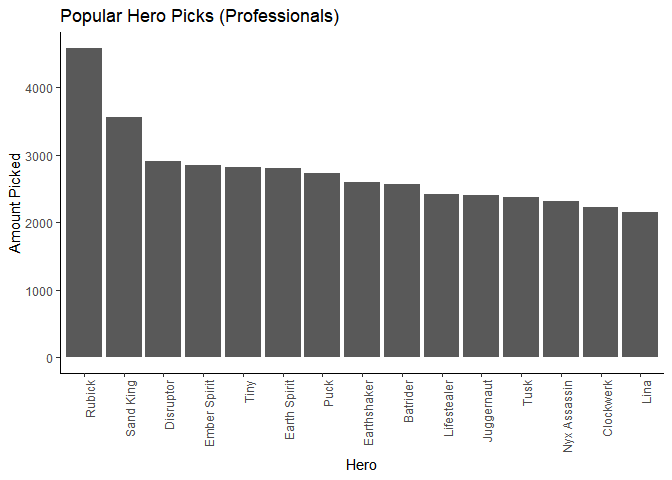

```r
library(dplyr)
# then we will choose the top 15 most picked heroes for the patch range
total_hero %>%  top_n(15,Total_Games_Picked)  %>%
# Just setting up the bar Graph, reorder allows to sort how the data is displayed
ggplot(aes(x=reorder(Hero,-Total_Games_Picked) , y = Total_Games_Picked)) +
geom_bar(stat="identity")  + theme_classic() +
theme(axis.text.x = element_text(angle = 90, hjust = 1)) +
labs(title = "Popular Hero Picks (Professionals)", y= "Amount Picked", x= "Hero")
```

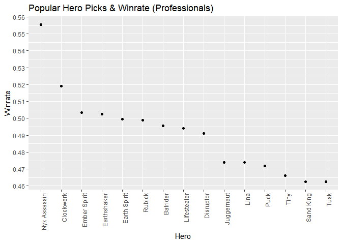

```r
library(dplyr)
total_hero %>%  top_n(15,Total_Games_Picked)  %>%
# Just setting up the bar Graph, reorder allows to sort how the data is displayed
ggplot(aes(x=reorder(Hero,-Winrate) , y = Winrate)) +
geom_point()  +
theme(axis.text.x = element_text(angle = 90, hjust = 1)) +  scale_y_continuous(breaks = scales::pretty_breaks(n = 10)) +
labs(title = "Popular Hero Picks & Winrate (Professionals)", y= "Winrate", x= "Hero")
```

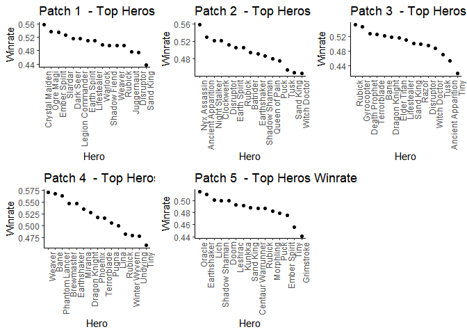

```r
## Create a function to handle the same graph code for each patch set
### uses paste function to concatenate the title names based on the patch number
GetGraph <- function(team, id) {
  p1 <- paste("Patch", id, sep = " ")
  p2 <- paste(p1, " - Top Heros Winrate", sep = " ")

  graph <- team%>%  top_n(15,Total_Games_Picked) %>%
    ggplot(aes(x=reorder(Hero,-Winrate) , y = Winrate)) +
    geom_point()   + theme_classic() +
    theme(axis.text.x = element_text(angle = 90, hjust = 1)) +
    labs(title = p2, y= "Winrate", x= "Hero")

  return(graph)
}

# Bind the graph results
df1 <- GetGraph(hero_patchset_1, "1")
df2 <- GetGraph(hero_patchset_2, "2")
df3 <- GetGraph(hero_patchset_3,"3")
df4 <- GetGraph(hero_patchset_4,"4")
df5 <-GetGraph(hero_patchset_5,"5")

# we use ggpubr to arrange the graphs together
ggarrange(df1,df2,df3,df4,df5)
```

Let’s continue analyzing the data, but this time, will we use regression models to look at the relationships between multiple variables. First, we will look at the relationship between Hero pick rate and their win rate. Further, we can also use facet_grids to show the relationship change over the interval of patches that change the game.

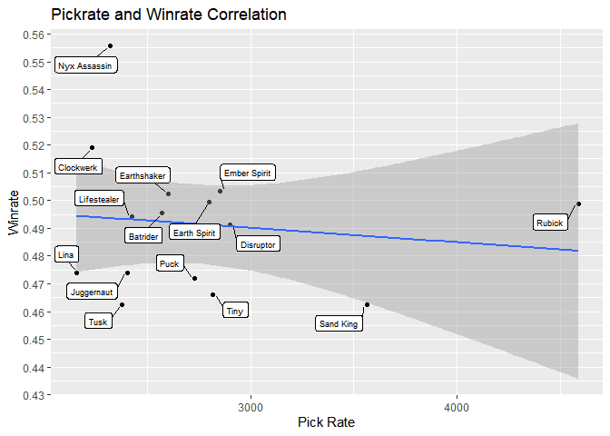

```r
library(ggplot2)
library(tidyverse)
library(magrittr)
library(ggrepel)

ggplot(total_hero %>%  top_n(15,Total_Games_Picked)  %>%
  group_by(Hero, Winrate),
  aes(x=Total_Games_Picked, y = Winrate)) +
  geom_point() +
  geom_smooth(method=lm) +
  geom_label_repel(aes(label = Hero), point.padding = .4, box.padding = 0.2, size = 2.5) +
  scale_y_continuous(breaks = scales::pretty_breaks(n = 10))  +
labs(title = "Pickrate and Winrate Correlation", y= "Winrate", x= "Pick Rate")
```

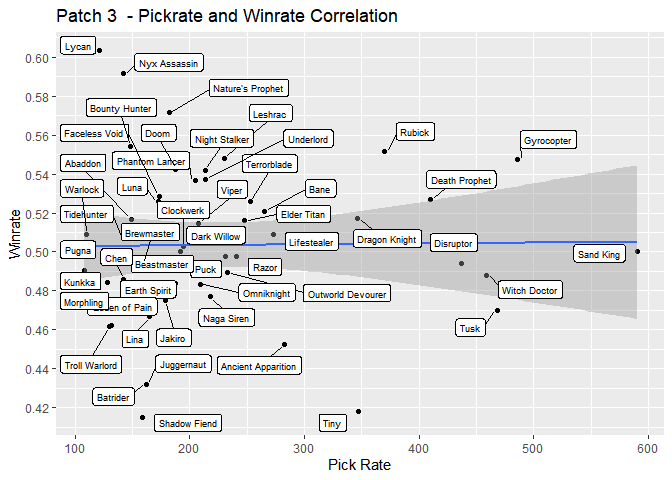

```r
## Create a function to handle the same graph code for each patch set
### uses paste function to concatenate the title names based on the patch number
GetGraph <- function(team, id) {
  p1 <- paste("Patch", id, sep = " ")
  p2 <- paste(p1, " - Pickrate and Winrate Correlation", sep = " ")

  graph <-
    ggplot(team%>%  top_n(50,Total_Games_Picked) %>%
     group_by(Hero, Winrate),
  aes(x=Total_Games_Picked, y = Winrate)) +
  geom_point() +
  geom_smooth(method=lm) +
  geom_label_repel(aes(label = Hero), point.padding = .4, box.padding = 0.2, size = 2.5) +
  scale_y_continuous(breaks = scales::pretty_breaks(n = 10))  +
labs(title = p2, y= "Winrate", x= "Pick Rate")

  return(graph)
}

# Bind the graph results
df1 <- GetGraph(hero_patchset_1, "1")
df2 <- GetGraph(hero_patchset_2, "2")
df3 <- GetGraph(hero_patchset_3,"3")
df4 <- GetGraph(hero_patchset_4,"4")
df5 <-GetGraph(hero_patchset_5,"5")

# I dropped patches 1,4 to conserve space.
# they had the least number of games played before the next patch.
df3
```

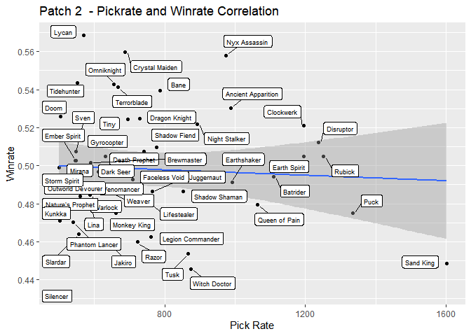

```r
df2
```

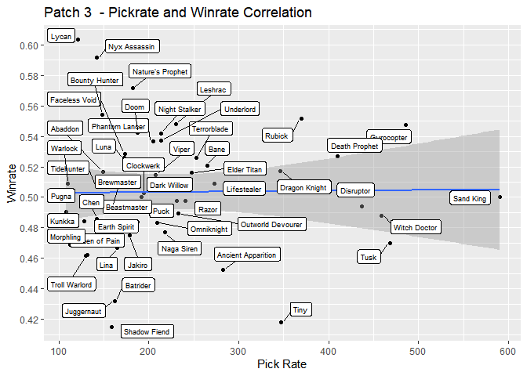

```r
df3
```

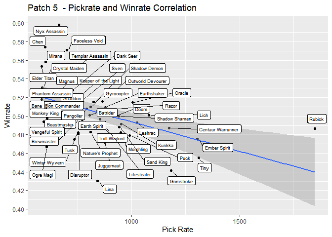

```r
df5
```

There appears to be some variation between patches, but there does seem to be a slight lead in winrates for heroes who aren’t picked that often. As the pick rate increases, their win rate appears to get closer to 50%. Heros that aren’t picked often may have been picked for special situations, for specific advantages, so this does make sense.

Let’s look at something different but still apply some regression techniques:

(1 The goal of the game is to destroy the opponents main building, so heroes who do the most tower damage should be expected to have a higher win rate due to more buildings being destroyed.

2. Heros who “kill” their opponents during the game also gain the advantage of them having to wait to respawn. This gives them a strategic advantage of being able to maximize this time to gain a lead in multiple ways (destroy buildings, gain gold, etc). We can do this by looking at hero kills amount, and/or hero total damage.

There are many other areas we could explore such as hero levels and winrate correlation, and we can also start applying match time being a factor into all of these. I suggest you try these for yourself!

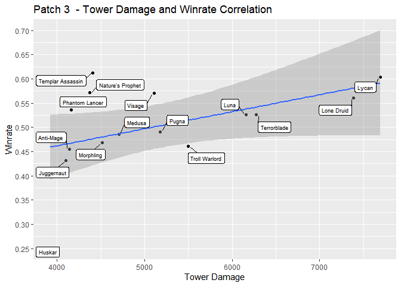

```r
## Create a function to handle the same graph code for each patch set
### uses paste function to concatenate the title names based on the patch number
GetGraph <- function(team, id) {
  p1 <- paste("Patch", id, sep = " ")
  p2 <- paste(p1, " - Tower Damage and Winrate Correlation", sep = " ")

  graph <-
    ggplot(team%>%  top_n(15,Tower_Damage) %>%
     group_by(Hero, Winrate),
  aes(x=Tower_Damage, y = Winrate)) +
  geom_point() +
  geom_smooth(method=lm) +
  geom_label_repel(aes(label = Hero), point.padding = .4, box.padding = 0.2, size = 2.5) +
  scale_y_continuous(breaks = scales::pretty_breaks(n = 10))  +
labs(title = p2, y= "Winrate", x= "Tower Damage")

  return(graph)
}

# Bind the graph results
df1 <- GetGraph(hero_patchset_1, "1")
df2 <- GetGraph(hero_patchset_2, "2")
df3 <- GetGraph(hero_patchset_3,"3")
df4 <- GetGraph(hero_patchset_4,"4")
df5 <-GetGraph(hero_patchset_5,"5")

# I dropped patches 1,4 to conserve space.
# they had the least number of games played before the next patch.
df3
```

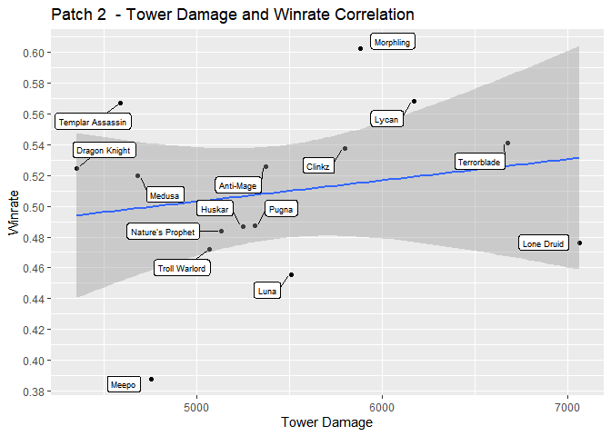

```r
df2
```

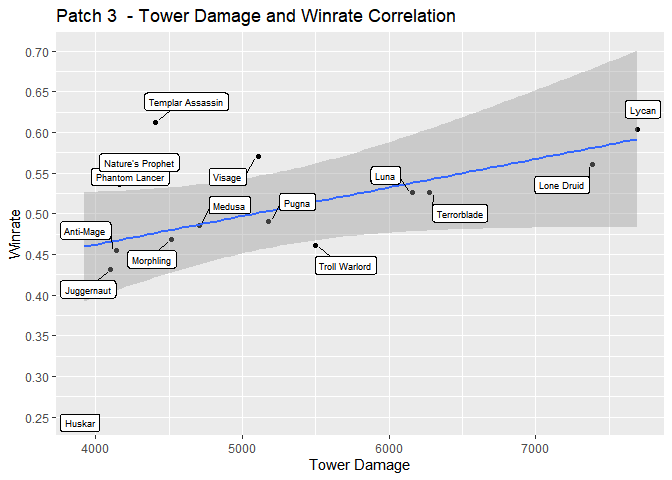

```r
df3
```

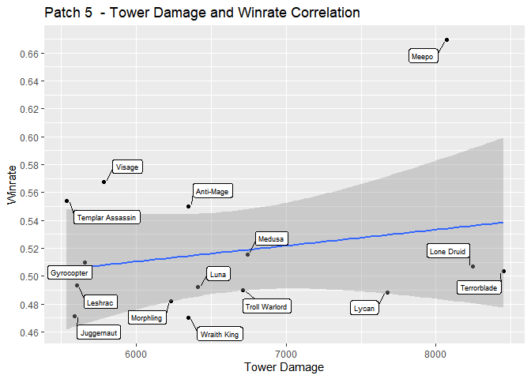

```r
df5
```

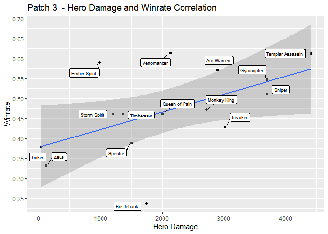

```r
## Create a function to handle the same graph code for each patch set
### uses paste function to concatenate the title names based on the patch number
GetGraph <- function(team, id) {
  p1 <- paste("Patch", id, sep = " ")
  p2 <- paste(p1, " - Hero Damage and Winrate Correlation", sep = " ")

  graph <-
    ggplot(team%>%  top_n(15,Hero_Damage) %>%
     group_by(Hero, Winrate),
  aes(x=Tower_Damage, y = Winrate)) +
  geom_point() +
  geom_smooth(method=lm) +
  geom_label_repel(aes(label = Hero), point.padding = .4, box.padding = 0.2, size = 2.5) +
  scale_y_continuous(breaks = scales::pretty_breaks(n = 10))  +
labs(title = p2, y= "Winrate", x= "Hero Damage")

  return(graph)
}

# Bind the graph results
df1 <- GetGraph(hero_patchset_1, "1")
df2 <- GetGraph(hero_patchset_2, "2")
df3 <- GetGraph(hero_patchset_3,"3")
df4 <- GetGraph(hero_patchset_4,"4")
df5 <-GetGraph(hero_patchset_5,"5")

# I dropped patches 1,4 to conserve space.
# they had the least number of games played before the next patch.
df3
```

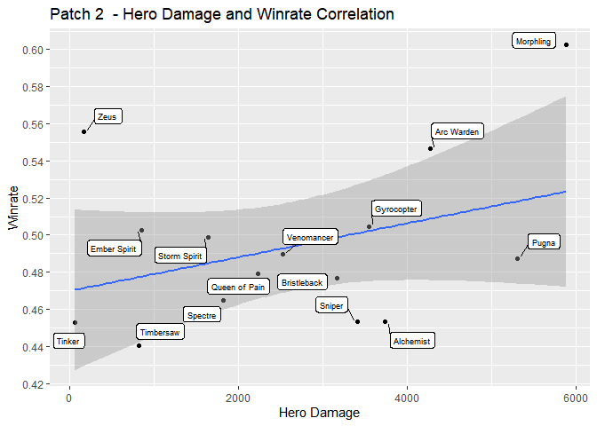

```r
df2
```

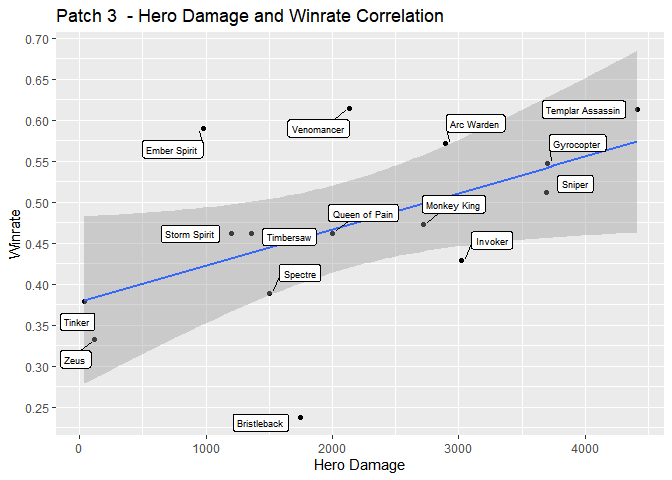

```r
df3
```

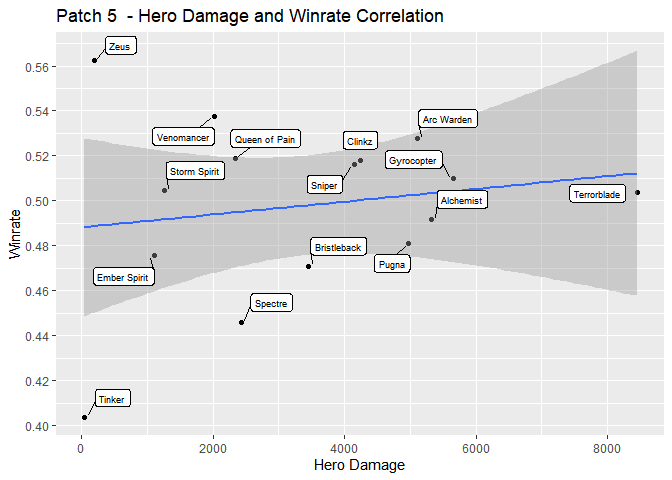

```r
df5
```

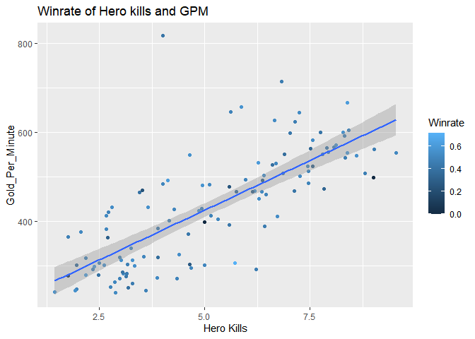

```r
## Create a function to handle the same graph code for each patch set
### uses paste function to concatenate the title names based on the patch number
GetGraph <- function(team, id) {
  p1 <- paste("Patch", id, sep = " ")
  p2 <- paste(p1, " - Hero Damage and Winrate Correlation", sep = " ")

  graph <-
    ggplot(team,aes(x = Kills, y = Gold_Per_Minute ,color=Winrate))+
  geom_point()+
  geom_smooth(method=lm)+
  labs(title = "Winrate of Hero kills and GPM",
       x = "Hero Kills",
       y = "Gold_Per_Minute")

  return(graph)
}

# Bind the graph results
df1 <- GetGraph(hero_patchset_1, "1")
df2 <- GetGraph(hero_patchset_2, "2")
df3 <- GetGraph(hero_patchset_3,"3")
df4 <- GetGraph(hero_patchset_4,"4")
df5 <-GetGraph(hero_patchset_5,"5")

# I dropped patches 1,4 to conserve space.
# they had the least number of games played before the next patch.
df3
```

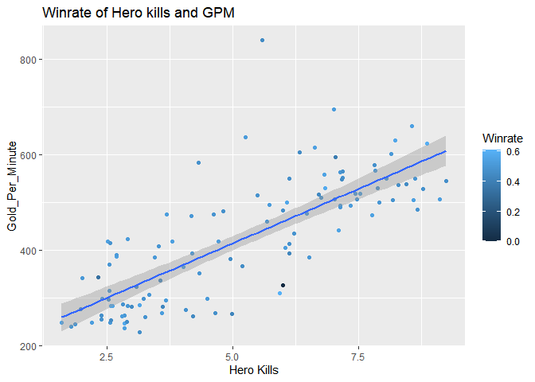

```r
df2
```

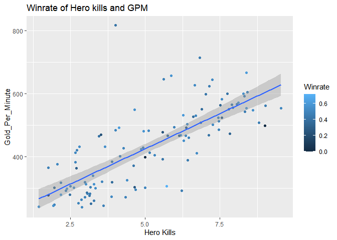

```r
df3
```

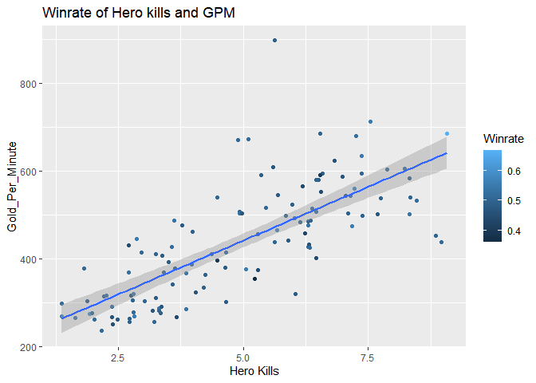

```r
df5
```

A hero who kills their opponent gains gold, so it makes sense to see an increase of gold per minute for the number of kills to increase. This doesn’t always mean the game is in the bag though, because the other team can still easily come back with the “come back” mechanics of the game. The team compositions also can have different performance peaks during the match, so this can allow teams to take over at different points of the game. This isn’t guarenteed though.

# Machine Learning